# Linear Regression - Part 2

Model Evaluation

14/03/2022

# PART 2: 2nd WEEK OF LINEAR REGRESSION RMD FILE:

# How to evaluate models

Suppose we are trying to predict the price of diamonds.

```r
library(tidyverse)
library(modelr)
set.seed(1)
diamonds10k <- diamonds %>%
  sample_n(10000) %>%
  mutate(cut_ord = cut,
         color_ord = forcats::fct_relevel(color, rev(levels(color))),
         clarity_ord = clarity,
         cut = as.character(cut_ord),
         color = as.character(color_ord),
         clarity = as.character(clarity_ord))

diamonds10k
```

```
## # A tibble: 10,000 x 13
##    carat cut       color clarity depth table price     x     y     z cut_ord
##    <dbl> <chr>     <chr> <chr>   <dbl> <dbl> <int> <dbl> <dbl> <dbl> <ord>
##  1  0.41 Very Good D     SI2      62.3    61   638  4.72  4.75  2.95 Very Good
##  2  0.5  Very Good F     VS2      62.8    57  1402  5.05  5.08  3.18 Very Good
##  3  1.03 Fair      I     SI2      65.2    56  3530  6.42  6.35  4.16 Fair
##  4  1.1  Ideal     I     SI1      62.1    57  5037  6.6   6.64  4.11 Ideal
##  5  1.51 Very Good E     VS2      63.3    61 13757  7.24  7.17  4.56 Very Good
##  6  0.3  Ideal     H     VS2      62.1    55   457  4.3   4.33  2.68 Ideal
##  7  0.87 Premium   J     SI1      61.4    57  2321  6.17  6.14  3.78 Premium
##  8  1.05 Very Good H     VS1      63.3    57  5657  6.45  6.4   4.07 Very Good
##  9  1    Good      F     SI1      64      57  4372  6.29  6.33  4.04 Good
## 10  2.01 Good      I     SI1      63.8    57 13976  7.95  7.91  5.06 Good
## # ... with 9,990 more rows, and 2 more variables: color_ord <ord>,
## #   clarity_ord <ord>
```

We are considering two models:

```r
fit1 <- lm(log10(price) ~ log2(carat), data=diamonds10k)
```

```r
fit2 <- lm(log10(price) ~ log2(carat) + cut + color + clarity, data=diamonds10k)
```

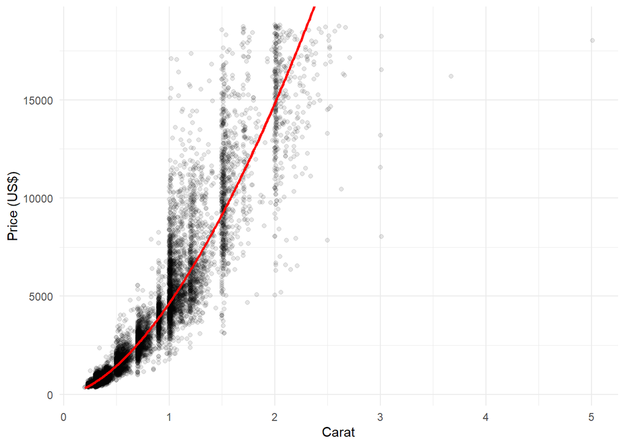

```r
diamonds10k %>%
  add_predictions(fit1, "log10pred") %>%
  mutate(pred = 10^log10pred) %>%
  ggplot(aes(x=carat)) +
  geom_point(aes(y=price), alpha=0.1) +
  geom_line(aes(y=pred), color="red", size=1) +
  coord_cartesian(xlim=range(diamonds10k$carat),
                  ylim=range(diamonds10k$price)) +
  labs(x="Carat", y="Price (US$)") +
  theme_minimal()
```

How can we know which model is better?

# Metrics for evaluating models

Some common metrics for evaluating regression models:

- Goodness-of-fit measures
  - R-squared: proportion of variance explained
  - Akaike Information Criterion (AIC)
  - Bayesian Information Criterion (BIC)
- Predictive ability
  - Root mean squared error (RMSE)
  - Mean absolute error (MAE)

# Goodness-of-fit

We’ll use the `broom` package to extract some goodness-of-fit statistics for our two models.

```r
library(broom)
glance(fit1)
```

```
## # A tibble: 1 x 12
##   r.squared adj.r.squared sigma statistic p.value    df logLik     AIC     BIC
##       <dbl>         <dbl> <dbl>     <dbl>   <dbl> <dbl>  <dbl>   <dbl>   <dbl>
## 1     0.932         0.932 0.115   136131.       0     1  7436. -14867. -14845.
## # ... with 3 more variables: deviance <dbl>, df.residual <int>, nobs <int>
```

```r
glance(fit2)
```

```
## # A tibble: 1 x 12
##   r.squared adj.r.squared  sigma statistic p.value    df logLik     AIC     BIC
##       <dbl>         <dbl>  <dbl>     <dbl>   <dbl> <dbl>  <dbl>   <dbl>   <dbl>
## 1     0.983         0.983 0.0579    31479.       0    18 14308. -28576. -28432.
## # ... with 3 more variables: deviance <dbl>, df.residual <int>, nobs <int>
```

## R-squared

R-squared can be interpreted as the variation in the response variable that has been explained by the predictors in the model.

This interpretation can be seen from one possible formulation of R-squared as:

- R-squared = 1 - var(residuals) / var(total)

Since R-squared ranges from 0 to 1, it has a straightforward interpretation, and values closer to 1 are typically seen as stronger models.

A problem with R-squared is that it always increases as additional variables are added. Adjusted R-squared can be used to avoid this issue.

However, neither R-squared nor adjusted R-squared measure predictive ability or usefulness of a model for statistical inference, so other metrics are preferable.

## AIC and BIC

The AIC and BIC are criteria are likelihood-based criteria that can be useful for comparing candidate models when prediction on new data is not required.

Both protect over-fitting by penalizing the number of parameters in the model, but in slightly different ways.

```r
AIC(fit1)
```

```
## [1] -14866.55
```

```r
AIC(fit2)
```

```
## [1] -28576.08
```

Smaller values indicate a better fit.

```r
BIC(fit1)
```

```
## [1] -14844.92
```

```r
BIC(fit2)
```

```
## [1] -28431.87
```

Neither value has a direct interpretation.

However, minimizing AIC is equivalent to minimizing the KL-divergence between the observed data and the predicted values.

Minimizing BIC is equivalent to maximizing the posterior likelihood of the data given the model.

# Predictive ability

## RMSE

The root mean squared error (RMSE) is a common way of measuring accuracy in regression problems.

RMSE is calculated as the square root of the mean of squared errors.

```r
sqrt(mean(resid(fit1)^2)) # direct calculation
```

```
## [1] 0.1150296
```

```r
modelr::rmse(fit1, diamonds10k) # convenience
```

```
## [1] 0.1150296
```

```r
modelr::rmse(fit2, diamonds10k)
```

```
## [1] 0.05785922
```

Due to using the squared errors, RMSE is sensitive to outliers and large errors.

Smaller RMSEs are better.

## MAE

Mean absolute error (MAE) offers a more easily-interpretable alternative to RMSE

```r
mean(abs(resid(fit1))) # direct calculation
```

```
## [1] 0.08923749
```

```r
modelr::mae(fit1, diamonds10k) # convenience
```

```
## [1] 0.08923749
```

```r
modelr::mae(fit2, diamonds10k)
```

```
## [1] 0.04509515
```

Because it uses absolute values rather than squared errors, it is less sensitive to outliers and large errors.

Smaller MAEs are better.

## Over-fitting

Over-fitting is a problem with evaluating predictive ability on the same data that we used to fit the model.

Our measures are too optimistic compared to predicting on new data.

In fact, adding more variables always improves the accuracy.

```r
fit3 <- lm(log10(price) ~ log2(carat) + cut + color + clarity +
             x + y + z, data=diamonds10k)

fit4 <- lm(log10(price) ~ log2(carat) + cut + color + clarity +
             x + y + z + depth + table, data=diamonds10k)
```

More variables keeps improving RMSE.

```r
rmse(fit1, diamonds10k) # 1 variable
```

```
## [1] 0.1150296
```

```r
rmse(fit2, diamonds10k) # 4 variables
```

```
## [1] 0.05785922
```

```r
rmse(fit3, diamonds10k) # 7 variables
```

```
## [1] 0.05778118
```

```r
rmse(fit4, diamonds10k) # 9 variables
```

```
## [1] 0.0577808
```

We observe the same with the MAE.

```r
mae(fit1, diamonds10k) # 1 variable
```

```
## [1] 0.08923749
```

```r
mae(fit2, diamonds10k) # 4 variables
```

```
## [1] 0.04509515
```

```r
mae(fit3, diamonds10k) # 7 variables
```

```
## [1] 0.04497434
```

```r
mae(fit4, diamonds10k) # 9 variables
```

```
## [1] 0.04497377
```

After a certain point, we are learning the noise in the dataset rather than the true signal.

# Training and testing

In order to calculate an accurate measure of predictive ability on new data, we need to test our model on data that has not been used to train it.

## Partitioning the dataset

We can test our model on “new” data by partitioning our data beforehand.

- A **training** set for EDA and training candidate models
- A **validation** set for comparing and selecting models
- A **test** set for testing the final model

We need a validation set if we are comparing models, because it’s also possible to over-fit in the model selection process.

We can use `modelr::resample_partition()` to partition the dataset.

```r
set.seed(2)
diamonds_part <- resample_partition(diamonds10k,
                                    p=c(train=0.6,
                                        valid=0.2,
                                        test=0.2))

diamonds_part
```

```
## $train
## <resample [5,999 x 13]> 1, 3, 4, 5, 6, 8, 10, 16, 17, 19, ...
##
## $valid
## <resample [2,000 x 13]> 7, 12, 14, 18, 21, 25, 27, 35, 40, 48, ...
##
## $test
## <resample [2,001 x 13]> 2, 9, 11, 13, 15, 20, 23, 37, 38, 41, ...
```

## Training

Let’s re-train the models on the training set.

```r
fit_t1 <- lm(log10(price) ~ log2(carat), data=diamonds_part$train)

fit_t2 <- lm(log10(price) ~ log2(carat) + cut + color + clarity,
             data=diamonds_part$train)

fit_t3 <- lm(log10(price) ~ log2(carat) + cut + color + clarity +
               x + y + z, data=diamonds_part$train)

fit_t4 <- lm(log10(price) ~ log2(carat) + cut + color + clarity +
               x + y + z + depth + table, data=diamonds_part$train)
```

## Validation

We can compare the models on the validation set.

```r
rmse(fit_t1, diamonds_part$valid) # 1 variable
```

```
## [1] 0.1145832
```

```r
rmse(fit_t2, diamonds_part$valid) # 4 variables
```

```
## [1] 0.05919583
```

```r
rmse(fit_t3, diamonds_part$valid) # 7 variables
```

```
## [1] 0.05908551
```

```r
rmse(fit_t4, diamonds_part$valid) # 9 variables
```

```
## [1] 0.05909086
```

We select the best model with the lowest RMSE on the validation set.

Note that the most complex model (with the most variables) is no longer the best. It was over-fitting on the training set, as revealed by performing worse than a simpler model on the validation set.

## Testing

Finally, we can test the selected model on the test set.

```r
rmse(fit_t3, diamonds_part$test)
```

```
## [1] 0.05678092
```

This process gives us a more accurate measure of our model’s predictive ability for new data.

# Cross-validation

Cross-validation gives us a way to use a larger portion of our data for both training and validation.

- Partition the data in *k* subsets
- Repeat *k* times:
  - Hold out one of the *k* subsets for testing
  - Train model on the other pool of *k - 1* subsets
  - Test the model on the subset held out for testing
- Calcualte average predictive performance over all *k* folds

## Partitioning data for CV

We can use `modelr::crossv_kfold()` to partition the dataset for cross-validation.

The result is a data frame with list-columns. The columns are lists containing the training and test sets for each fold.

```r
set.seed(3)

diamonds_train <- diamonds10k[-diamonds_part$test$idx,]

diamonds_cv <- crossv_kfold(diamonds_train, 5)

diamonds_cv
```

```
## # A tibble: 5 x 3
##   train                   test                    .id
##   <named list>            <named list>            <chr>
## 1 <resample [6,399 x 13]> <resample [1,600 x 13]> 1
## 2 <resample [6,399 x 13]> <resample [1,600 x 13]> 2
## 3 <resample [6,399 x 13]> <resample [1,600 x 13]> 3
## 4 <resample [6,399 x 13]> <resample [1,600 x 13]> 4
## 5 <resample [6,400 x 13]> <resample [1,599 x 13]> 5
```

## Performing CV

Below we use `map()` to fit models to all of the training sets, and then calculate their RMSEs.

The `purrr::map()` function is similar to `lapply()`, but provides a syntactic sugar for writing anonymous functions using a formula interface.

Note that:

- `purrr::map(x, ~ .)`

is equivalent to:

- `lapply(x, function(xi) xi)`

```r
cv_t1 <- diamonds_cv %>%
  mutate(fit = purrr::map(train,
                   ~ lm(log10(price) ~ log2(carat), data = .)),
         rmse = purrr::map2_dbl(fit, test, ~ rmse(.x, .y)))

cv_t1
```

```
## # A tibble: 5 x 5
##   train                   test                    .id   fit           rmse
##   <named list>            <named list>            <chr> <named list> <dbl>
## 1 <resample [6,399 x 13]> <resample [1,600 x 13]> 1     <lm>         0.116
## 2 <resample [6,399 x 13]> <resample [1,600 x 13]> 2     <lm>         0.114
## 3 <resample [6,399 x 13]> <resample [1,600 x 13]> 3     <lm>         0.119
## 4 <resample [6,399 x 13]> <resample [1,600 x 13]> 4     <lm>         0.114
## 5 <resample [6,400 x 13]> <resample [1,599 x 13]> 5     <lm>         0.116
```

Now we can get the cross-validated RMSE.

```r
mean(cv_t1$rmse)
```

```
## [1] 0.1158021
```

## Comparing models using CV

To more easily compare models using cross-validation, let’s first write a function for performing CV on the diamonds dataset for any given model formula.

```r
do_diamonds_cv <- function(formula) {
  diamonds_cv %>%
    mutate(fit = map(train,
                     ~ lm(formula, data = .)),
         rmse = map2_dbl(fit, test, ~ rmse(.x, .y))) %>%
    summarize(cv_rmse = mean(rmse)) %>%
    pull(cv_rmse)
}
```

Now we can use our function to perform cross-validation on our four models.

```r
do_diamonds_cv(log10(price) ~ log2(carat))
```

```
## [1] 0.1158021
```

```r
do_diamonds_cv(log10(price) ~ log2(carat) + cut + color + clarity)
```

```
## [1] 0.05833255
```

```r
do_diamonds_cv(log10(price) ~ log2(carat) + cut + color + clarity +
                 x + y + z)
```

```
## [1] 0.05957154
```

```r
do_diamonds_cv(log10(price) ~ log2(carat) + cut + color + clarity +
                 x + y + z + depth + table)
```

```
## [1] 0.05987084
```

For very similarly-performing models, the random partitioning can have an effect on the choice of best model.

This time, we would select a different model than before.

```r
fit_cv_t2 <- lm(log10(price) ~ log2(carat) + cut + color + clarity,
                data=diamonds_train)

rmse(fit_cv_t2, diamonds_part$test)
```

```
## [1] 0.05681101
```

# Model selection

In the above examples, we only compared four models.

How do we know those are the best combinations of variables?

We need a way of methodically comparing models and selecting the best variables to use for prediction.

## Stepwise selection

Stepwise selection is a greedy procedure in which we iteratively add/drop the best/worst variable to the model.

In forward selection, we begin with an empty model (no candidate variables), and at each step, we add the variable that improves the model the most.

In backward elimination, we begin with a full model (all candidate variables), and at each step, we drop the variable that contributes the least to the model.

Below, we write a function for performing one step using RMSE.

```r
step1 <- function(response, predictors, candidates, partition)
{
  rhs <- paste0(paste0(predictors, collapse="+"), "+", candidates)
  formulas <- lapply(paste0(response, "~", rhs), as.formula)
  rmses <- sapply(formulas,
                  function(fm) rmse(lm(fm, data=partition$train),
                                    data=partition$valid))
  names(rmses) <- candidates
  attr(rmses, "best") <- rmses[which.min(rmses)]
  rmses
}
```

Let’s initialize a variable for tracking out model.

```r
model <- NULL
```

Step 1 (no variables):

```r
preds <- "1"
cands <- c("log2(carat)", "cut", "color", "clarity",
          "x", "y", "z", "depth", "table")
s1 <- step1("log10(price)", preds, cands, diamonds_part)

model <- c(model, attr(s1, "best"))
s1
```

```
## log2(carat)         cut       color     clarity           x           y
##   0.1145832   0.4423867   0.4396712   0.4349203   0.1233836   0.1276280
##           z       depth       table
##   0.1426486   0.4465196   0.4386280
## attr(,"best")
## log2(carat)
##   0.1145832
```

Step 2:

```r
preds <- "log2(carat)"
cands <- c("cut", "color", "clarity",
          "x", "y", "z", "depth", "table")

s1 <- step1("log10(price)", preds, cands, diamonds_part)

model <- c(model, attr(s1, "best"))
s1
```

```
##        cut      color    clarity          x          y          z      depth
## 0.11130382 0.10390007 0.08242291 0.11451820 0.11446266 0.11474732 0.11388971
##      table
## 0.11390234
## attr(,"best")
##    clarity
## 0.08242291
```

Step 3:

```r
preds <- c("log2(carat)", "clarity")
cands <- c("cut", "color",
          "x", "y", "z", "depth", "table")

s1 <- step1("log10(price)", preds, cands, diamonds_part)

model <- c(model, attr(s1, "best"))
s1
```

```
##        cut      color          x          y          z      depth      table
## 0.08154019 0.06073670 0.08244083 0.08241689 0.08248340 0.08213694 0.08232365
## attr(,"best")
##     color
## 0.0607367
```

Step 4:

```r
preds <- c("log2(carat)", "clarity", "color")
cands <- c("cut",
          "x", "y", "z", "depth", "table")

s1 <- step1("log10(price)", preds, cands, diamonds_part)

model <- c(model, attr(s1, "best"))
s1
```

```
##        cut          x          y          z      depth      table
## 0.05919583 0.06037178 0.06061110 0.06070771 0.06059174 0.06056275
## attr(,"best")
##        cut
## 0.05919583
```

Step 5:

```r
preds <- c("log2(carat)", "clarity", "color", "cut")
cands <- c("x", "y", "z", "depth", "table")

s1 <- step1("log10(price)", preds, cands, diamonds_part)

model <- c(model, attr(s1, "best"))
s1
```

```
##          x          y          z      depth      table
## 0.05908524 0.05915600 0.05910836 0.05919573 0.05919500
## attr(,"best")
##          x
## 0.05908524
```

Step 6:

```r
preds <- c("log2(carat)", "clarity", "color", "cut",
           "x")
cands <- c("y", "z", "depth", "table")

s1 <- step1("log10(price)", preds, cands, diamonds_part)

model <- c(model, attr(s1, "best"))
s1
```

```
##          y          z      depth      table
## 0.05908793 0.05907686 0.05908103 0.05908221
## attr(,"best")
##          z
## 0.05907686
```

Step 7 (stop):

```r
preds <- c("log2(carat)", "clarity", "color", "cut",
           "x", "z")
cands <- c("y", "depth", "table")

s1 <- step1("log10(price)", preds, cands, diamonds_part)

model <- c(model, attr(s1, "best"))
s1
```

```
##          y      depth      table
## 0.05908551 0.05907739 0.05907804
## attr(,"best")
##      depth
## 0.05907739
```

At this point, the RMSE has increased, so we would stop, and not include `depth` in our final model.

We can visualize how adding each variable affects the RMSE.

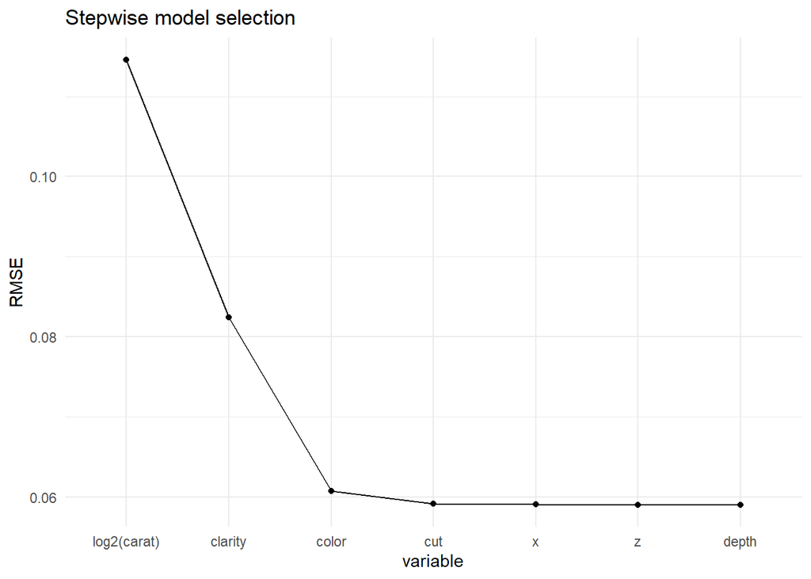

```r
step_model <- tibble(index=seq_along(model),
                     variable=factor(names(model), levels=names(model)),
                     RMSE=model)

ggplot(step_model, aes(y=RMSE)) +
  geom_point(aes(x=variable)) +
  geom_line(aes(x=index)) +
  labs(title="Stepwise model selection") +
  theme_minimal()
```

After adding `color`, each additional variable has significantly less effect on improving the RMSE, until adding `depth` makes the model worse.

## Other options

Other options for selecting the best variables to include in a model:

- Contextual knowledge
  - Background knowledge and common sense can help greatly in determining which variables should not be included
- Exhaustive search
  - While computationally-intensive, it would be possible to try all combinations of variables
- Sparse methods
  - Sparse methods use regularization to automatically select variables by shrinking coefficients for less-important variables to zero